# Clustering

## 10/14/2021

print view

```python
%%html
<script src="http://bits.csb.pitt.edu/asker.js/lib/asker.js"></script>
<script>

require(['https://cdnjs.cloudflare.com/ajax/libs/Chart.js/2.2.2/Chart.js'], function(Ch){
 Chart = Ch;
});

$('head').append('<link rel="stylesheet" href="http://bits.csb.pitt.edu/asker.js/themes/asker.default.css" />');


//the callback is provided a canvas object and data
var chartmaker = function(canvas, labels, data) {
  var ctx = $(canvas).get(0).getContext("2d");
     var dataset = {labels: labels,
    datasets:[{
     data: data,
     backgroundColor: "rgba(150,64,150,0.5)",
         fillColor: "rgba(150,64,150,0.8)",
  }]};
  var myBarChart = new Chart(ctx,{type:'bar',data:dataset,options:{legend: {display:false},
        scales: {
            yAxes: [{
                ticks: {
                    min: 0,
                }
            }]}}});
};

$(".jp-InputArea .o:contains(html)").closest('.jp-InputArea').hide();


</script>
```

What is clustering?

Wikipedia: Cluster analysis or clustering is the task of grouping a set of objects in such a way that objects in the same group (called a cluster) are more similar (in some sense or another) to each other than to those in other groups (clusters).

Generally speaking, clustering is NP-hard, so it is difficult to identify a provable optimal clustering.

[figure not shown]

# What is *similar*?

- *similarity*: larger number means *more* similar
  - Tanimoto (or Jaccard) similarity of two sets: $$\frac{|A \cap B|}{|A \cup B|}$$
- *distance*: larger number means *less* similar (zero means identical)
  - Euclidean distance (L2 norm) between $n$-dimensional vectors $u$ and $v$: $$\|u - v\|_2 = \sqrt{\sum_i^n (u_i - v_i)^2}$$
  - Cityblock (Manhattan) distance (L1 norm): $$\|u - v\|_1 = \sum_i^n|u_i - v_i|$$
  - Cosine distance between $n$-dimensional vectors $u$ and $v$: $$1 - \frac{u \cdot v}{\|u\|_2 \|v\|_2}$$

```python
%%html
<div id="tanimotosim" style="width: 500px"></div>
<script>
$('head').append('<link rel="stylesheet" href="http://bits.csb.pitt.edu/asker.js/themes/asker.default.css" />');

    var divid = '#tanimotosim';
	jQuery(divid).asker({
	    id: divid,
	    question: "What is the range for Tanimoto similarity?",
		answers: ['0...1','-inf...inf','0...inf','-1...1'],
        server: "http://bits.csb.pitt.edu/asker.js/example/asker.cgi",
		charter: chartmaker})

$(".jp-InputArea .o:contains(html)").closest('.jp-InputArea').hide();


</script>
```

Given two vectors $u = (0,1)$ and $v = (2,0)$

```python
%%html
<div id="euclideanuv" style="width: 500px"></div>
<script>
$('head').append('<link rel="stylesheet" href="http://bits.csb.pitt.edu/asker.js/themes/asker.default.css" />');

    var divid = '#euclideanuv';
	jQuery(divid).asker({
	    id: divid,
	    question: "What Euclidean distance between u and v?",
		answers: ['0','1','2','2.23','3','5'],
        server: "http://bits.csb.pitt.edu/asker.js/example/asker.cgi",
		charter: chartmaker})

$(".jp-InputArea .o:contains(html)").closest('.jp-InputArea').hide();


</script>
```

Given two vectors $u = (0,1)$ and $v = (2,0)$

```python
%%html
<div id="cityblockuv" style="width: 500px"></div>
<script>
$('head').append('<link rel="stylesheet" href="http://bits.csb.pitt.edu/asker.js/themes/asker.default.css" />');

    var divid = '#cityblockuv';
	jQuery(divid).asker({
	    id: divid,
	    question: "What cityblock distance between u and v?",
		answers: ['0','1','2','2.23','3','5'],
        server: "http://bits.csb.pitt.edu/asker.js/example/asker.cgi",
		charter: chartmaker})

$(".jp-InputArea .o:contains(html)").closest('.jp-InputArea').hide();


</script>
```

Given two vectors $u = (0,1)$ and $v = (2,0)$

```python
%%html
<div id="cosineuv" style="width: 500px"></div>
<script>
$('head').append('<link rel="stylesheet" href="http://bits.csb.pitt.edu/asker.js/themes/asker.default.css" />');

    var divid = '#cosineuv';
	jQuery(divid).asker({
	    id: divid,
	    question: "What cosine distance between u and v?",
		answers: ['0','1','2','2.23','3','5'],
        server: "http://bits.csb.pitt.edu/asker.js/example/asker.cgi",
		charter: chartmaker})

$(".jp-InputArea .o:contains(html)").closest('.jp-InputArea').hide();


</script>
```

```python
import scipy.spatial.distance
help(scipy.spatial.distance)
```

[output not shown]

[output cut: 1654 more lines]

[output not shown]

# k-means clustering

In *k-means clustering* we are given a set of $d$-dimensional vectors and we want to identify *k* sets $S_i$ such that

$$\sum_{i=0}^k \sum_{x_j \in S_i} ||x_j - \mu_i||^2$$

is **minimized** where $\mu_i$ is the *mean* of cluster $S_i$. That is, all points are close as possible to the 'center' of the cluster.

**Limitations**

- Classical k-means requires that we be able to take an average of our points - *no arbitrary distance functions*.
- Must provide $k$ as a parameter - bad $k$, bad clustering.

# k-means clustering

**General algorithm**

- Choose initial set of $k$ cluster centers (centroids/means).
- Compute means of these clusters.
- Reassign points using updated means.
- Repeat

Will converge to **local** optimum.

http://bits.csb.pitt.edu/kmeans/

# scipy vector quantization

First let's make a toy data set...

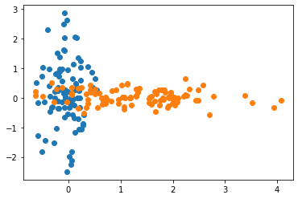

```python
import scipy.cluster.vq as vq #vq: vector quantization
import numpy as np
import matplotlib.pylab as plt
%matplotlib inline
randpts1 = np.random.randn(100,2)/(4,1) #100 integer coordinates in the range [0:50],[0:50]
randpts2 = (np.random.randn(100,2)+(1,0))/(1,4)
plt.plot(randpts1[:,0],randpts1[:,1],'o',randpts2[:,0],randpts2[:,1],'o')
randpts = np.vstack((randpts1,randpts2))
```

# scipy vector quantization

```python
(means,clusters) = vq.kmeans2(randpts,2)#returns tuple of means and cluster assignments
```

The means are the cluster centers

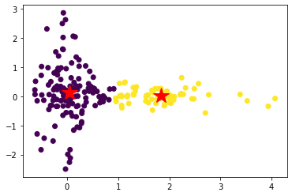

```python
plt.scatter(randpts[:,0],randpts[:,1],c=clusters)
plt.plot(means[:,0],means[:,1],'*',ms=20,c='red');
```

## Changing k

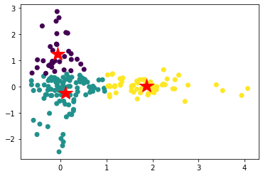

```python
(means,clusters) = vq.kmeans2(randpts,3)
plt.scatter(randpts[:,0],randpts[:,1],c=clusters)
plt.plot(means[:,0],means[:,1],'*',ms=20,c='red');
```

## Changing k

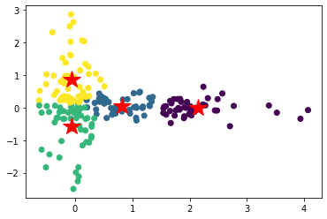

```python
(means,clusters) = vq.kmeans2(randpts,4)
plt.scatter(randpts[:,0],randpts[:,1],c=clusters)
plt.plot(means[:,0],means[:,1],'*',ms=20,c='red');
```

```python
%%html
<div id="kmean" style="width: 500px"></div>
<script>
$('head').append('<link rel="stylesheet" href="http://bits.csb.pitt.edu/asker.js/themes/asker.default.css" />');

    var divid = '#kmean';
	jQuery(divid).asker({
	    id: divid,
	    question: "Will k-means always find the same set of clusters?",
		answers: ['Yes','No','Depends'],
        server: "http://bits.csb.pitt.edu/asker.js/example/asker.cgi",
		charter: chartmaker})

$(".jp-InputArea .o:contains(html)").closest('.jp-InputArea').hide();


</script>
```

# scipy vector quantization

Vector quantization is just a fancy way to describe assigning clusters to new points.

```python
newrand = np.random.randn(100,2)
code,dist = vq.vq(newrand,means)
```

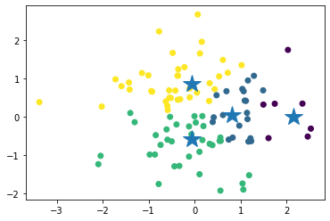

```python
plt.scatter(newrand[:,0],newrand[:,1],c=code)
plt.plot(means[:,0],means[:,1],'*',ms=20);
```

```python
%%html
<div id="clus1" style="width: 500px"></div>
<script>
$('head').append('<link rel="stylesheet" href="http://bits.csb.pitt.edu/asker.js/themes/asker.default.css" />');

    var divid = '#clus1';
	jQuery(divid).asker({
	    id: divid,
	    question: "What sort of data would k-means have difficulty clustering?",
		answers: ['Expression data','Dose-response data','Protein structures','Sequences'],
        server: "http://bits.csb.pitt.edu/asker.js/example/asker.cgi",
		charter: chartmaker})

$(".jp-InputArea .o:contains(html)").closest('.jp-InputArea').hide();


</script>
```

# Hierarchical Clustering

Hierarchical clustering creates a heirarchy, where each cluster is formed from subclusters.

[figure not shown]

# Agglomerative clustering

Agglomerative builds this hierarchy from the *bottom up*: start with all singleton clusters, find the two clusters that are closest, combine them into a cluster, repeat.

This requires there be a notion of distance between *clusters of items*, not just the items themselves.

**Important:** All you need is a distance function - you do *not* need to be able to take an average (as with k-means).

# Distance (Linkage) Methods

[figure not shown]

- **average**: $$d(u,v) = \sum_{ij}\frac{d(u_i,v_j)}{|u||v|}$$
- **complete** or farthest point: $$d(u,v) = \max(dist(u_i,v_j))$$
- **single** or nearest point: $$d(u,v) = \min(dist(u_i,v_j))$$

```python
%%html

<img src="imgs/clusterpoints.png">
<div id="cluspts" style="width: 500px"></div>
<script>
$('head').append('<link rel="stylesheet" href="http://bits.csb.pitt.edu/asker.js/themes/asker.default.css" />');

    var divid = '#cluspts';
	jQuery(divid).asker({
	    id: divid,
	    question: "What cluster is closest to red by single linkage? complete?",
		answers: ['blue, blue','blue, yellow','yellow, blue','yellow, yellow'],
        server: "http://bits.csb.pitt.edu/asker.js/example/asker.cgi",
		charter: chartmaker})

$(".jp-InputArea .o:contains(html)").closest('.jp-InputArea').hide();


</script>
```

[figure not shown]

# `linkage`

`scipy.cluster.hierarchy.linkage` creates a clustering hierarchy. It takes three parameters:

- *y* the data or a precalculated distance matrix
- *method* the linkage method (default single)
- *metric* the distance metric to use (default euclidean)

```python
import scipy.cluster.hierarchy as hclust
linkage_matrix = hclust.linkage(randpts)
```

```
A (n−1) by 4 matrix Z is returned. At the i-th iteration, clusters with indices Z[i, 0] and Z[i, 1] are combined to form cluster n+i. A cluster with an index less than n corresponds to one of the n original observations. The distance between clusters Z[i, 0] and Z[i, 1] is given by Z[i, 2]. The fourth value Z[i, 3] represents the number of original observations in the newly formed cluster.
```

```python
linkage_matrix.shape
```

```
(199, 4)
```

```python
linkage_matrix
```

```
array([[7.20000000e+01, 8.00000000e+01, 7.37839982e-03, 2.00000000e+00],
       [1.30000000e+02, 1.50000000e+02, 8.18702215e-03, 2.00000000e+00],
       [1.59000000e+02, 1.81000000e+02, 1.13948288e-02, 2.00000000e+00],
       [4.30000000e+01, 9.30000000e+01, 1.22954249e-02, 2.00000000e+00],
       [9.40000000e+01, 2.03000000e+02, 1.24791671e-02, 3.00000000e+00],
       [1.83000000e+02, 1.85000000e+02, 1.51331941e-02, 2.00000000e+00],
       [7.80000000e+01, 9.20000000e+01, 1.92513453e-02, 2.00000000e+00],
       [5.80000000e+01, 7.60000000e+01, 1.98622153e-02, 2.00000000e+00],
       [4.00000000e+00, 9.10000000e+01, 2.22829969e-02, 2.00000000e+00],
       [1.60000000e+01, 6.30000000e+01, 2.23643626e-02, 2.00000000e+00],
       [1.46000000e+02, 1.78000000e+02, 2.62585217e-02, 2.00000000e+00],
       [2.50000000e+01, 3.20000000e+01, 2.75559769e-02, 2.00000000e+00],
       [1.66000000e+02, 1.99000000e+02, 2.80316729e-02, 2.00000000e+00],
       [4.10000000e+01, 6.50000000e+01, 3.02058667e-02, 2.00000000e+00],
       [1.70000000e+01, 2.08000000e+02, 3.04431757e-02, 3.00000000e+00],
       [1.90000000e+02, 2.05000000e+02, 3.05349543e-02, 3.00000000e+00],
       [5.90000000e+01, 6.00000000e+01, 3.10319345e-02, 2.00000000e+00],
       [7.50000000e+01, 2.11000000e+02, 3.16901071e-02, 3.00000000e+00],
       [1.21000000e+02, 1.69000000e+02, 3.28721149e-02, 2.00000000e+00],
       [7.90000000e+01, 1.06000000e+02, 3.46733130e-02, 2.00000000e+00],
       [1.29000000e+02, 2.02000000e+02, 3.59765678e-02, 3.00000000e+00],
       [1.64000000e+02, 1.93000000e+02, 3.70276787e-02, 2.00000000e+00],
       [1.00000000e+02, 1.25000000e+02, 3.80034539e-02, 2.00000000e+00],
       [1.00000000e+01, 1.13000000e+02, 3.80824917e-02, 2.00000000e+00],
       [1.52000000e+02, 1.74000000e+02, 3.86117541e-02, 2.00000000e+00],
       [2.30000000e+01, 1.42000000e+02, 3.88409774e-02, 2.00000000e+00],
       [1.12000000e+02, 2.24000000e+02, 3.93506241e-02, 3.00000000e+00],
       [1.20000000e+01, 2.19000000e+02, 4.01065012e-02, 3.00000000e+00],
       [5.00000000e+00, 2.60000000e+01, 4.03947189e-02, 2.00000000e+00],
       [2.00000000e+01, 8.30000000e+01, 4.49468965e-02, 2.00000000e+00],
       [1.07000000e+02, 1.26000000e+02, 4.54744010e-02, 2.00000000e+00],
       [1.61000000e+02, 1.67000000e+02, 4.58606999e-02, 2.00000000e+00],
       [9.00000000e+00, 4.80000000e+01, 4.80055963e-02, 2.00000000e+00],
       [1.11000000e+02, 2.31000000e+02, 4.91872425e-02, 3.00000000e+00],
       [6.80000000e+01, 8.50000000e+01, 5.03950759e-02, 2.00000000e+00],
       [1.96000000e+02, 2.21000000e+02, 5.16967971e-02, 3.00000000e+00],
       [2.10000000e+01, 2.13000000e+02, 5.21830122e-02, 3.00000000e+00],
       [1.90000000e+01, 7.00000000e+01, 5.46517606e-02, 2.00000000e+00],
       [1.01000000e+02, 1.62000000e+02, 5.62004585e-02, 2.00000000e+00],
       [1.10000000e+02, 1.54000000e+02, 5.62204869e-02, 2.00000000e+00],
```

[output cut: 144 more lines]

```
       [3.77000000e+02, 3.82000000e+02, 2.65211925e-01, 1.72000000e+02],
       [1.68000000e+02, 1.84000000e+02, 2.97933584e-01, 2.00000000e+00],
       [1.76000000e+02, 3.84000000e+02, 3.23649917e-01, 1.73000000e+02],
       [3.54000000e+02, 3.86000000e+02, 3.47365882e-01, 1.77000000e+02],
       [2.80000000e+01, 3.80000000e+02, 3.53582640e-01, 4.00000000e+00],
       [1.40000000e+02, 3.87000000e+02, 3.58633394e-01, 1.78000000e+02],
       [5.60000000e+01, 3.67000000e+02, 3.81201689e-01, 4.00000000e+00],
       [4.70000000e+01, 3.89000000e+02, 3.90893890e-01, 1.79000000e+02],
       [3.68000000e+02, 3.91000000e+02, 3.98727885e-01, 1.82000000e+02],
       [3.88000000e+02, 3.92000000e+02, 4.30943678e-01, 1.86000000e+02],
       [3.90000000e+02, 3.93000000e+02, 4.36982263e-01, 1.90000000e+02],
       [3.81000000e+02, 3.94000000e+02, 4.46075726e-01, 1.95000000e+02],
       [3.83000000e+02, 3.85000000e+02, 4.52422414e-01, 4.00000000e+00],
       [1.70000000e+02, 3.95000000e+02, 5.32137670e-01, 1.96000000e+02],
       [3.96000000e+02, 3.97000000e+02, 6.13464886e-01, 2.00000000e+02]])
```

# Dendograms

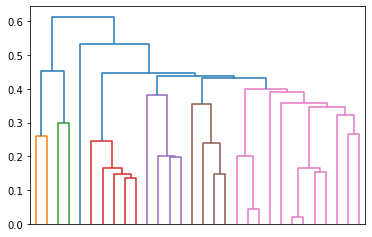

```python
hclust.dendrogram(linkage_matrix,p=10,truncate_mode='level',no_labels=True);#show first 10 levels
```

*The cophenetic distance between two observations that have been clustered is defined to be the intergroup dissimilarity at which the two observations are first combined into a single cluster. It is shown as the height of the U-links.*

# `fcluster`: extracting clusters from a hierarchy

`fcluster` takes a linkage matrix and returns a cluster assignment. It takes a threshold value and a string specifying what method to use to form the cluster.

```python
help(hclust.fcluster)
```

```
Help on function fcluster in module scipy.cluster.hierarchy:

fcluster(Z, t, criterion='inconsistent', depth=2, R=None, monocrit=None)
    Form flat clusters from the hierarchical clustering defined by
    the given linkage matrix.

    Parameters
    ----------
    Z : ndarray
        The hierarchical clustering encoded with the matrix returned
        by the `linkage` function.
    t : scalar
        For criteria 'inconsistent', 'distance' or 'monocrit',
         this is the threshold to apply when forming flat clusters.
        For 'maxclust' or 'maxclust_monocrit' criteria,
         this would be max number of clusters requested.
    criterion : str, optional
        The criterion to use in forming flat clusters. This can
        be any of the following values:

          ``inconsistent`` :
              If a cluster node and all its
              descendants have an inconsistent value less than or equal
              to `t`, then all its leaf descendants belong to the
              same flat cluster. When no non-singleton cluster meets
              this criterion, every node is assigned to its own
              cluster. (Default)

          ``distance`` :
              Forms flat clusters so that the original
              observations in each flat cluster have no greater a
              cophenetic distance than `t`.

          ``maxclust`` :
              Finds a minimum threshold ``r`` so that
              the cophenetic distance between any two original
              observations in the same flat cluster is no more than
              ``r`` and no more than `t` flat clusters are formed.

          ``monocrit`` :
```

[output cut: 96 more lines]

```
    array([1, 1, 1, 1, 1, 1, 1, 1, 1, 1, 1, 1], dtype=int32)

    In the first case, the threshold ``t`` is too small to allow any two
    samples in the data to form a cluster, so 12 different clusters are
    returned.

    In the second case, the threshold is large enough to allow the first
    4 points to be merged with their nearest neighbors. So, here, only 8
    clusters are returned.

    The third case, with a much higher threshold, allows for up to 8 data
    points to be connected - so 4 clusters are returned here.

    Lastly, the threshold of the fourth case is large enough to allow for
    all data points to be merged together - so a single cluster is returned.
```

The inconsistency coefficient for each link is computed by comparing its height with the average height of other links at the same level of the hierarchy. The larger the coefficient, the greater the difference between the objects connected by the link.

$$\frac{Z_{i,2} - \textrm{mean}_i}{\textrm{std}_i}$$

## Flatten based on distance threshold

```python
clusters = hclust.fcluster(linkage_matrix,0.3,'distance')
len(set(clusters))
```

```
14
```

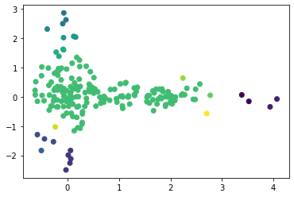

```python
plt.scatter(randpts[:,0],randpts[:,1],c=clusters);
```

## Flatten based on number of clusters

```python
clusters = hclust.fcluster(linkage_matrix,4,'maxclust')
len(set(clusters))
```

```
4
```

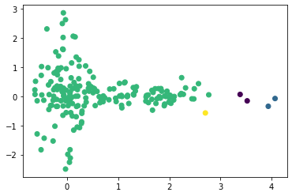

```python
plt.scatter(randpts[:,0],randpts[:,1],c=clusters)
```

# `fclusterdata`

`fclusterdata` does both linkage and fcluster in one step. Let's try out different linkage methods.

```
14
```

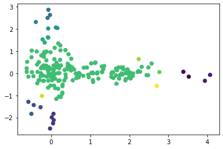

```python
clusters = hclust.fclusterdata(randpts,.3,criterion='distance',method='single')
plt.scatter(randpts[:,0],randpts[:,1],c=clusters)
len(set(clusters))
```

```
58
```

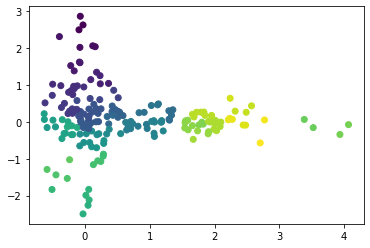

```python
clusters = hclust.fclusterdata(randpts,.3,criterion='distance',method='complete')
plt.scatter(randpts[:,0],randpts[:,1],c=clusters);
len(set(clusters))
```

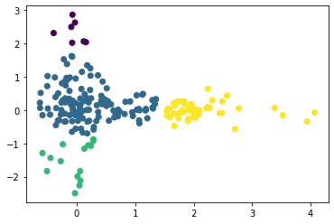

```python
clusters = hclust.fclusterdata(randpts,4,'maxclust',method='complete')
plt.scatter(randpts[:,0],randpts[:,1],c=clusters);
```

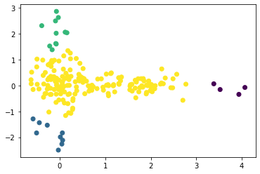

```python
clusters = hclust.fclusterdata(randpts,4,'maxclust',method='average')
plt.scatter(randpts[:,0],randpts[:,1],c=clusters);
```

You can even use a non-Euclidean metric.

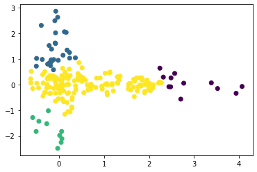

```python
clusters = hclust.fclusterdata(randpts,4,'maxclust',method='complete',metric='cityblock')
plt.scatter(randpts[:,0],randpts[:,1],c=clusters);
```

```python
%%html

<img src="imgs/roll.png">
<div id="clusroll" style="width: 500px"></div>
<script>
$('head').append('<link rel="stylesheet" href="http://bits.csb.pitt.edu/asker.js/themes/asker.default.css" />');

    var divid = '#clusroll';
	jQuery(divid).asker({
	    id: divid,
	    question: "What linkage was likely used to form these clusters?",
		answers: ['average','complete','single'],
        server: "http://bits.csb.pitt.edu/asker.js/example/asker.cgi",
		charter: chartmaker})

$(".jp-InputArea .o:contains(html)").closest('.jp-InputArea').hide();


</script>
```

[figure not shown]

# `leaves_list`

A hierarchical cluster imposes an order on the leaves. You can retrieve this ordering from the linkage matrix with `leaves_list`

```python
hclust.leaves_list(linkage_matrix)
```

```
array([131,  57, 129,  89,   0, 137,  27,  18,  58,  82, 102, 117,  30,
        19,  15,  77,  29,  32,  35,  94,  86,   3,  90,  98,  93,  80,
        59,  65,  26,  78,  13,  95,  99,  97,   8,  87,   7,  88,  11,
        17, 169, 179, 121, 173, 177,  70, 182,  37,  34,  81,  40,  53,
        72, 139, 192, 107,  52,  55,  64,  12,  16, 101, 151, 155, 105,
       166, 144, 149, 159, 120, 126,  56,  83, 161,  43, 111, 127,  54,
       167, 172, 168, 175,  24,  68,   9,  96,  22,  51,  62,  25,  49,
        71,  60,  84, 160,   5,  79,   4,   6, 189, 176, 174,  10, 154,
        14, 150,  21,  42,  47,  48,  91,  31,  67, 188, 157, 170,  39,
         1,  20,  38,  69,  73, 109,  28,  46,  75,  41,  63, 115, 184,
        66,  85,  61,   2,  74, 187,  50,  45,  92,  44, 148,  76,  33,
        23,  36, 128, 114, 163, 130, 104, 124, 142, 112, 100, 140, 190,
       162, 171, 132, 153, 119, 138, 118, 195, 123, 108, 185, 122, 178,
       145, 199, 147, 136, 143, 181, 186, 110, 180, 193, 125, 191, 116,
       197, 158, 152, 106, 103, 196, 156, 134, 183, 135, 113, 198, 141,
       133, 146, 164, 165, 194], dtype=int32)
```

[figure not shown]

```python
plt.figure(figsize=(16,3))
hclust.dendrogram(linkage_matrix);
```

```python
%%html
<div id="listorder" style="width: 500px"></div>
<script>
$('head').append('<link rel="stylesheet" href="http://bits.csb.pitt.edu/asker.js/themes/asker.default.css" />');

    var divid = '#listorder';
	jQuery(divid).asker({
	    id: divid,
	    question: "Is this order unique for a given linkage matrix?",
		answers: ['Yes','No'],
        server: "http://bits.csb.pitt.edu/asker.js/example/asker.cgi",
		charter: chartmaker})

$(".jp-InputArea .o:contains(html)").closest('.jp-InputArea').hide();


</script>
```

# Project: Cluster Expression Data

- Download https://asinansaglam.github.io/python_bio_2022/files/Spellman.csv
- read the expression data into a numpy array (hint: `np.genfromtxt`)
- cluster it with the default parameters
- retrieve the leaves
- reorder the orginal data according the the leaf order
- display the result as a heatmap (`plt.matshow`)
- try different distance metrics and linkages - what gives the best result?

```python
!wget https://asinansaglam.github.io/python_bio_2022/files/Spellman.csv
```